# Reto2

Blockchain Patrol

2023-11-17

# Crypto Datathon Reto 2

```r
library(data.table)
library(tidyverse)
library(readr)
library(ggplot2)
library(PerformanceAnalytics)
library(dygraphs)
library(tidyr)
library(cluster)
library(NbClust)
library(fpc)
library(factoextra)
library(corrplot)
library(ggpubr)
library(purrr)
library(jsonlite)
```

Los order books que tenemos tienen horas con milisegundos, por lo que vamos a cambiar la opción para visualizar las fechas con este nivel de detalle.

```r
op <- options(digits.secs=3)
```

```r
load(file="crypto_orderbooks_agregados_ADA_USDT.Rda")
load(file="crypto_orderbooks_agregados_AVAX_USDT.Rda")
load(file="crypto_orderbooks_agregados_BTC_USDT.Rda")
load(file="crypto_orderbooks_agregados_DOT_USDT.Rda")
load(file="crypto_orderbooks_agregados_LTC_USDT.Rda")
load(file="crypto_orderbooks_agregados_MATIC_USDT.Rda")
load(file="crypto_orderbooks_agregados_SHIB_USDT.Rda")
load(file="crypto_orderbooks_agregados_SOL_USDT.Rda")
load(file="crypto_orderbooks_agregados_UNI_USDT.Rda")
load(file="crypto_orderbooks_agregados_XRP_USDT.Rda")
load(file="crypto_orderbooks_agregados_ETH_BTC.Rda")
load(file="crypto_orderbooks_agregados_DOGE_USDT.Rda")
```

Sentimiento compra-venta = ratio entre bids y asks. Un valor muy bajo implica que mucha gente quiere vender frente a poca gente que quiere comprar. Un valor muy alto implica que mucha gente quiere comprar frente a poca gente que quiere vender.

## Calcula y define métricas que permitan configurar un sistema de alertas

```r
setNAsVariables <- function(datos){
    finBinance<-FALSE
    i<-1
    while (finBinance==FALSE && i<nrow(datos)){
      if(datos[i,]$Exchange=='binance'){
        finBinance<-TRUE
        datos[i,]$varPrecioMedioBids<-NA
        datos[i,]$varProfundidadBids<-NA
        datos[i,]$varPrecioMedioAsks<-NA
        datos[i,]$varProfundidadAsks<-NA
        datos[i,]$tiempoLlegada<-NA
      }
      i<-i+1
    }
    finKucoin<-FALSE
    i<-1
    while (finKucoin==FALSE & i<nrow(datos)){
      if(datos[i,]$Exchange=='kucoin'){
        finKucoin<-TRUE
        datos[i,]$varPrecioMedioBids<-NA
        datos[i,]$varProfundidadBids<-NA
        datos[i,]$varPrecioMedioAsks<-NA
        datos[i,]$varProfundidadAsks<-NA
        datos[i,]$tiempoLlegada<-NA
      }
    i<-i+1
    }
    finokx<-FALSE
    i<-1
    while (finokx==FALSE & i<nrow(datos)){
      if(datos[i,]$Exchange=='okx'){
        finokx<-TRUE
        datos[i,]$varPrecioMedioBids<-NA
        datos[i,]$varProfundidadBids<-NA
        datos[i,]$varPrecioMedioAsks<-NA
        datos[i,]$varProfundidadAsks<-NA
        datos[i,]$tiempoLlegada<-NA
      }
    i<-i+1
    }
    return(datos)
}
```

Ahora utilizamos la función anterior para limpiar los lags erroneos

```r
datos_ADA_USDT <- datos_ADA_USDT[order(datos_ADA_USDT$Hora),]
datos_ADA_USDT<-setNAsVariables(datos_ADA_USDT)

datos_AVAX_USDT <- datos_AVAX_USDT[order(datos_AVAX_USDT$Hora),]
datos_AVAX_USDT<-setNAsVariables(datos_AVAX_USDT)

datos_BTC_USDT <- datos_BTC_USDT[order(datos_BTC_USDT$Hora),]
datos_BTC_USDT<-setNAsVariables(datos_DOGE_USDT)

datos_DOGE_USDT <- datos_DOGE_USDT[order(datos_DOGE_USDT$Hora),]
datos_DOGE_USDT<-setNAsVariables(datos_DOGE_USDT)

datos_DOT_USDT <- datos_DOGE_USDT[order(datos_DOT_USDT$Hora),]
datos_DOT_USDT<-setNAsVariables(datos_DOT_USDT)

datos_ETH_BTC <- datos_ETH_BTC[order(datos_ETH_BTC$Hora),]
datos_ETH_BTC<-setNAsVariables(datos_ETH_BTC)

datos_LTC_USDT <- datos_LTC_USDT[order(datos_LTC_USDT$Hora),]
datos_LTC_USDT<-setNAsVariables(datos_LTC_USDT)

datos_MATIC_USDT <- datos_MATIC_USDT[order(datos_MATIC_USDT$Hora),]
datos_MATIC_USDT<-setNAsVariables(datos_MATIC_USDT)

datos_SHIB_USDT <- datos_SHIB_USDT[order(datos_SHIB_USDT$Hora),]
datos_SHIB_USDT<-setNAsVariables(datos_SHIB_USDT)

datos_SOL_USDT <- datos_SOL_USDT[order(datos_SOL_USDT$Hora),]
datos_SOL_USDT<-setNAsVariables(datos_SOL_USDT)

datos_UNI_USDT <- datos_UNI_USDT[order(datos_UNI_USDT$Hora),]
datos_UNI_USDT<-setNAsVariables(datos_UNI_USDT)

datos_XRP_USDT <- datos_XRP_USDT[order(datos_XRP_USDT$Hora),]
datos_XRP_USDT<-setNAsVariables(datos_XRP_USDT)
```

## Encuentra patrones

Calculamos la correlación que hay entre las distintas métricas que hemos calculado.

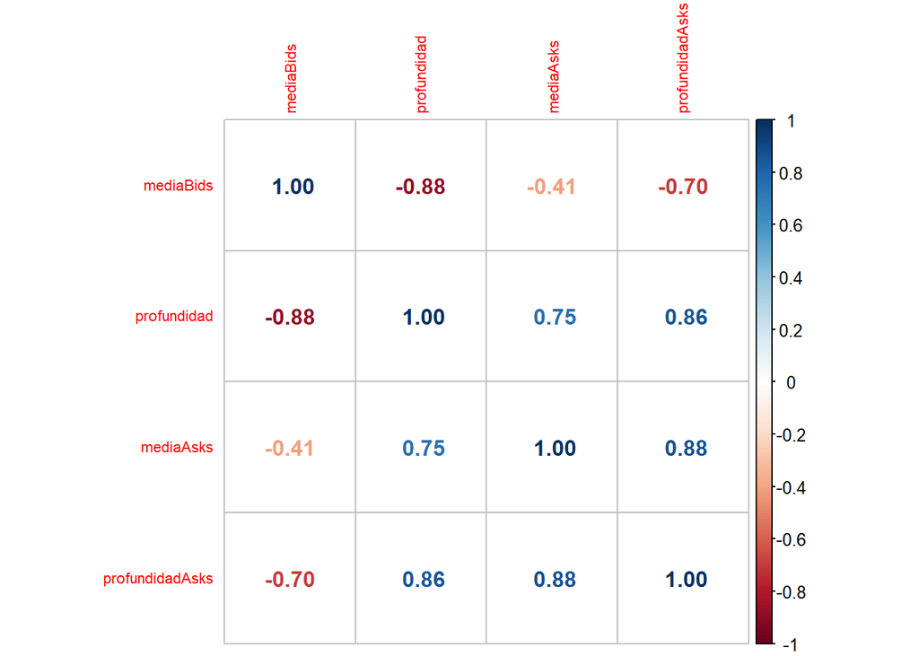

```r
VisualizarCorrelacion <- function(datos){
corrplot(cor(datos[, 4:7], use = "pairwise.complete.obs"), method = "number", addCoef.col = 1, tl.cex = 0.7)
}

#Aquí añadir el DF que queramos
VisualizarCorrelacion (datos_ADA_USDT)
```

Las correlaciones más fuertes parecen ser las siguientes: * Precio medio de bids - Profundidad de bids. Existe fuerte correlación negativa. * Profundidad de bids - Profundidad de asks. Existe fuerte correlación positiva. * Precio medio de asks - Profundidad de asks. Existe fuerte correlación positiva.

Podemos dibujar estas correlaciones a través de un gráfico de dispersión.

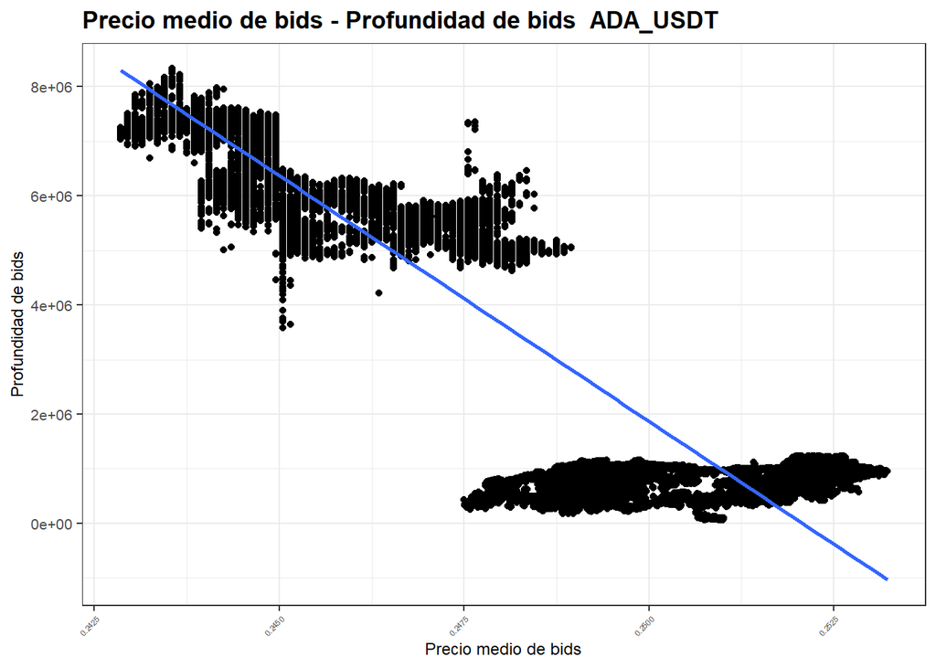

```r
VisualizarCorrelacionMediaBids_Profundidad <- function(datos, moneda){
ggplot(datos, aes(x = mediaBids, y = profundidad)) +
  geom_point() +
  geom_smooth(method=lm) +
  ggtitle(paste ("Precio medio de bids - Profundidad de bids " , moneda)) +
  theme_bw() +
  theme(axis.text = element_text(size = 8), axis.title =  element_text(size = 9), plot.title = element_text(face = 'bold'), axis.text.x = element_text(angle = 45, vjust = 1, hjust=1, size=4), strip.background=element_rect(colour="black", fill="#f4f4f4")) +
  labs(x = "Precio medio de bids", y = "Profundidad de bids")
}

#Poner el dataset que queramos
VisualizarCorrelacionMediaBids_Profundidad (datos_ADA_USDT, "ADA_USDT")
```

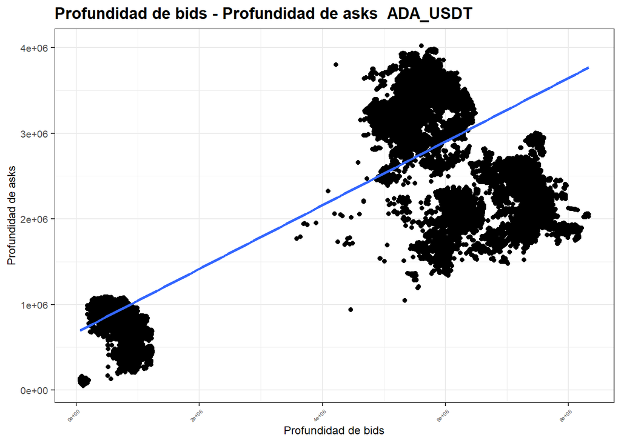

```r
VisualizarCorrelacionProfBids_ProfAsks <- function(datos, moneda){
ggplot(datos, aes(x = profundidad, y = profundidadAsks)) +
  geom_point() +
  geom_smooth(method=lm) +
  ggtitle(paste ("Profundidad de bids - Profundidad de asks ", moneda)) +
  theme_bw() +
  theme(axis.text = element_text(size = 8), axis.title =  element_text(size = 9), plot.title = element_text(face = 'bold'), axis.text.x = element_text(angle = 45, vjust = 1, hjust=1, size=4), strip.background=element_rect(colour="black", fill="#f4f4f4")) +
  labs(x = "Profundidad de bids", y = "Profundidad de asks")
}

#Poner el dataset que queramos
VisualizarCorrelacionProfBids_ProfAsks (datos_ADA_USDT, "ADA_USDT")
```

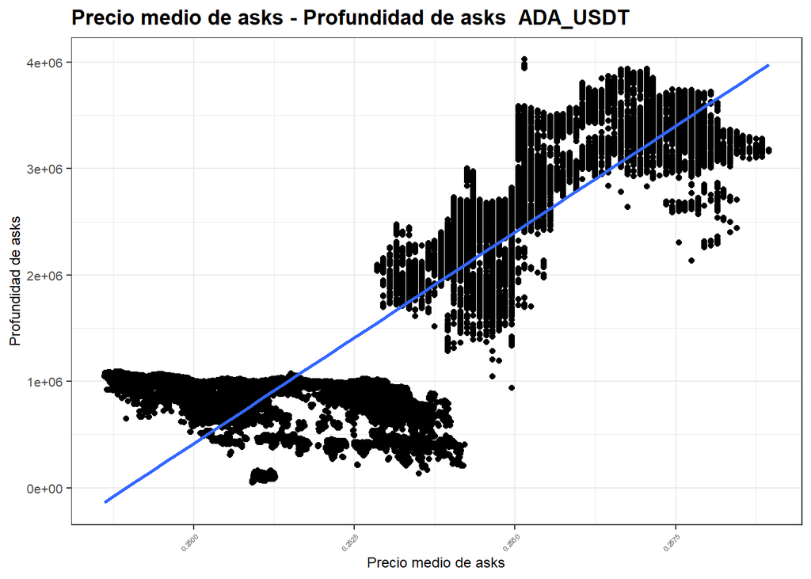

```r
VisualizarCorrelacionMediaAsks_ProfAsks <- function(datos, moneda){
ggplot(datos, aes(x = mediaAsks, y = profundidadAsks)) +
  geom_point() +
  geom_smooth(method=lm) +
  ggtitle(paste("Precio medio de asks - Profundidad de asks ", moneda)) +
  theme_bw() +
  theme(axis.text = element_text(size = 8), axis.title =  element_text(size = 9), plot.title = element_text(face = 'bold'), axis.text.x = element_text(angle = 45, vjust = 1, hjust=1, size=4), strip.background=element_rect(colour="#black", fill="#f4f4f4")) +
  labs(x = "Precio medio de asks", y = "Profundidad de asks")
}

#Poner el dataset que queramos
VisualizarCorrelacionMediaAsks_ProfAsks(datos_ADA_USDT, "ADA_USDT")
```

## Elije umbrales de comportamiento anómalo

Calculamos los cuantiles para las métricas calculadas para bids.

```r
CalculaCuantilesBids <- function(datos){
print ("Media Bids")
print(quantile(datos$mediaBids, c(.25, .50, .75)))
print ("Profundidad Bids")
print(quantile(datos$profundidad, c(.25, .50, .75)))
print ("Variación Precio Medio Bids")
print(quantile(datos$varPrecioMedioBids, c(.25, .50, .75), na.rm = T))
print ("Variación Profundidad Bids")
print(quantile(datos$varProfundidadBids, c(.25, .50, .75), na.rm = T))
}

#Poner el dataset que queramos
CalculaCuantilesBids(datos_ADA_USDT)
```

```
## [1] "Media Bids"
##       25%       50%       75%
## 0.2461500 0.2478500 0.2507597
## [1] "Profundidad Bids"
##       25%       50%       75%
##  720310.8 5077990.0 5814724.6
## [1] "Variación Precio Medio Bids"
## 25% 50% 75%
##   0   0   0
## [1] "Variación Profundidad Bids"
##          25%          50%          75%
## 0.0000000000 0.0000000000 0.0004961173
```

Y para asks

```r
CalculaCuantilesAsks <- function(datos){
print ("Media Asks")
print(quantile(datos$mediaAsks, c(.25, .50, .75)))
print ("Profundidad Asks")
print(quantile(datos$profundidadAsks, c(.25, .50, .75)))
print ("Variación Precio Medio Asks")
print(quantile(datos$varPrecioMedioAsks, c(.25, .50, .75), na.rm = T))
print ("Variación Profundidad Asks")
print(quantile(datos$varProfundidadAsks, c(.25, .50, .75), na.rm = T))
}

#Poner el dataset que queramos
CalculaCuantilesAsks(datos_ADA_USDT)
```

```
## [1] "Media Asks"
##      25%      50%      75%
## 0.252257 0.253850 0.256550
## [1] "Profundidad Asks"
##       25%       50%       75%
##  870811.9 1957762.0 3248755.5
## [1] "Variación Precio Medio Asks"
## 25% 50% 75%
##   0   0   0
## [1] "Variación Profundidad Asks"
## 25% 50% 75%
##   0   0   0
```

Dibujamos los gráficos de cajas para los valores medios de precios y profundidad, tanto para bids como para asks

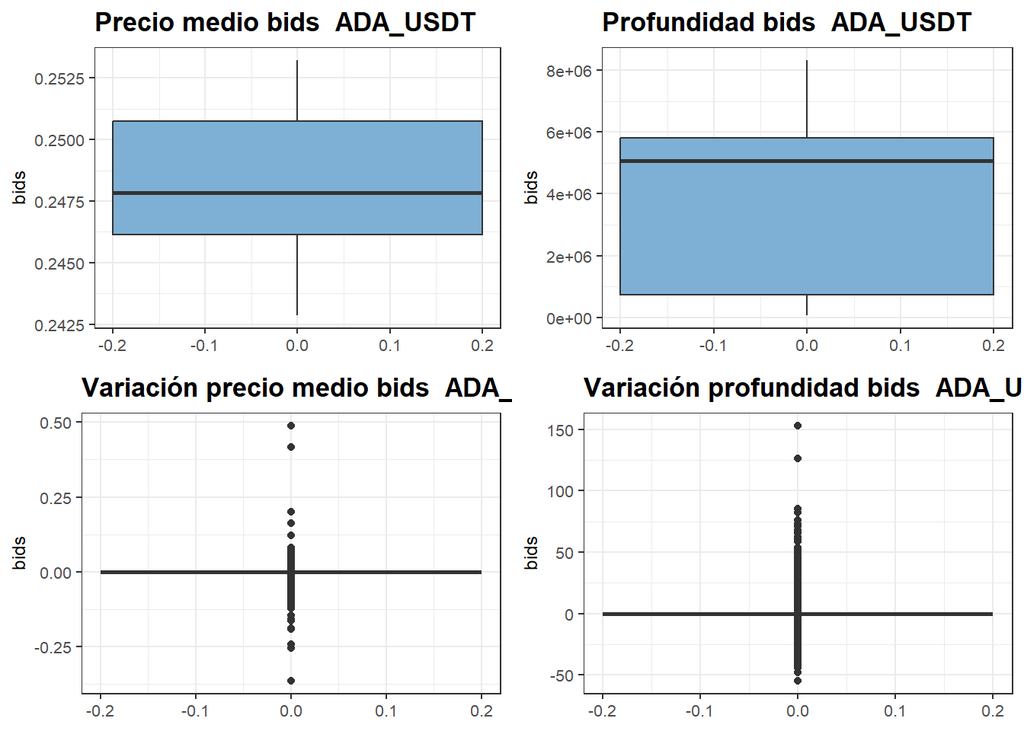

```r
PintarGraficoCajasBids <- function(datos, moneda){
p1 <- ggplot(datos, aes(y = mediaBids)) +
  geom_boxplot(width = 0.4, fill = "#7eb0d5") +
  ggtitle(paste ("Precio medio bids ", moneda)) +
  theme_bw() +
  theme(axis.text = element_text(size = 8), axis.title =  element_text(size = 9), plot.title = element_text(face = 'bold')) +
  labs(y = bquote(bids))

p2 <- ggplot(datos, aes(y = profundidad)) +
  geom_boxplot(width = 0.4, fill = "#7eb0d5") +
  ggtitle(paste("Profundidad bids ", moneda)) +
  theme_bw() +
  theme(axis.text = element_text(size = 8), axis.title =  element_text(size = 9), plot.title = element_text(face = 'bold')) +
  labs(y = bquote(bids))

p3 <- ggplot(datos, aes(y = varPrecioMedioBids)) +
  geom_boxplot(width = 0.4, fill = "#7eb0d5") +
  ggtitle(paste("Variación precio medio bids ", moneda)) +
  theme_bw() +
  theme(axis.text = element_text(size = 8), axis.title =  element_text(size = 9), plot.title = element_text(face = 'bold')) +
  labs(y = bquote(bids))

p4 <- ggplot(datos, aes(y = varProfundidadBids)) +
  geom_boxplot(width = 0.4, fill = "#7eb0d5") +
  ggtitle(paste("Variación profundidad bids ", moneda)) +
  theme_bw() +
  theme(axis.text = element_text(size = 8), axis.title =  element_text(size = 9), plot.title = element_text(face = 'bold')) +
  labs(y = bquote(bids))

ggarrange(ggarrange(p1, p2),
          ggarrange(p3, p4),
          nrow = 2
          )
}

#Poner el dataset que queramos
PintarGraficoCajasBids(datos_ADA_USDT, "ADA_USDT")
```

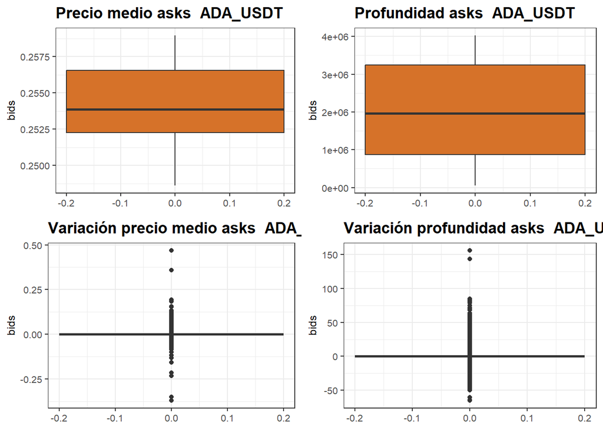

```r
PintarGraficoCajasAsks <- function(datos, moneda){
p1 <- ggplot(datos, aes(y = mediaAsks)) +
  geom_boxplot(width = 0.4, fill = "#d67229") +
  ggtitle(paste("Precio medio asks ", moneda)) +
  theme_bw() +
  theme(axis.text = element_text(size = 8), axis.title =  element_text(size = 9), plot.title = element_text(face = 'bold')) +
  labs(y = bquote(bids))

p2 <- ggplot(datos, aes(y = profundidadAsks)) +
  geom_boxplot(width = 0.4, fill = "#d67229") +
  ggtitle(paste("Profundidad asks ", moneda)) +
  theme_bw() +
  theme(axis.text = element_text(size = 8), axis.title =  element_text(size = 9), plot.title = element_text(face = 'bold')) +
  labs(y = bquote(bids))

p3 <- ggplot(datos, aes(y = varPrecioMedioAsks)) +
  geom_boxplot(width = 0.4, fill = "#d67229") +
  ggtitle(paste("Variación precio medio asks ", moneda)) +
  theme_bw() +
  theme(axis.text = element_text(size = 8), axis.title =  element_text(size = 9), plot.title = element_text(face = 'bold')) +
  labs(y = bquote(bids))

p4 <- ggplot(datos, aes(y = varProfundidadAsks)) +
  geom_boxplot(width = 0.4, fill = "#d67229") +
  ggtitle(paste ("Variación profundidad asks ", moneda)) +
  theme_bw() +
  theme(axis.text = element_text(size = 8), axis.title =  element_text(size = 9), plot.title = element_text(face = 'bold')) +
  labs(y = bquote(bids))

ggarrange(ggarrange(p1, p2),
          ggarrange(p3, p4),
          nrow = 2
          )
}

PintarGraficoCajasAsks(datos_ADA_USDT, "ADA_USDT")
```

## Visualización de los datos

```r
grafica_evolucion_media_bids <- function (datos, time_lag, titulo_grafico, y_label, i) {
  datos_agrupados <- datos %>%
    mutate(Hora_agrupada = cut(Hora, breaks = time_lag)) %>%
    group_by(Hora_agrupada) %>%
    summarize(mediaBidsAgrupada = mean(mediaBids)) %>%
    mutate(Hora_agrupada = as.POSIXct(Hora_agrupada))

  ggplot(datos_agrupados, aes(x = Hora_agrupada, y = mediaBidsAgrupada, group = 1)) +
    geom_line(size = 0.7, color = "#0047AB") +
    ggtitle(titulo_grafico) +
    theme_bw() +
    theme(axis.text = element_text(size = 8), axis.title =  element_text(size = 9), plot.title = element_text(face = 'bold')) +
    labs(x = element_blank(), y = y_label) +
    geom_hline(yintercept = quantile(datos_agrupados$mediaBidsAgrupada, c(.05, .95)), color = "red")
}
```

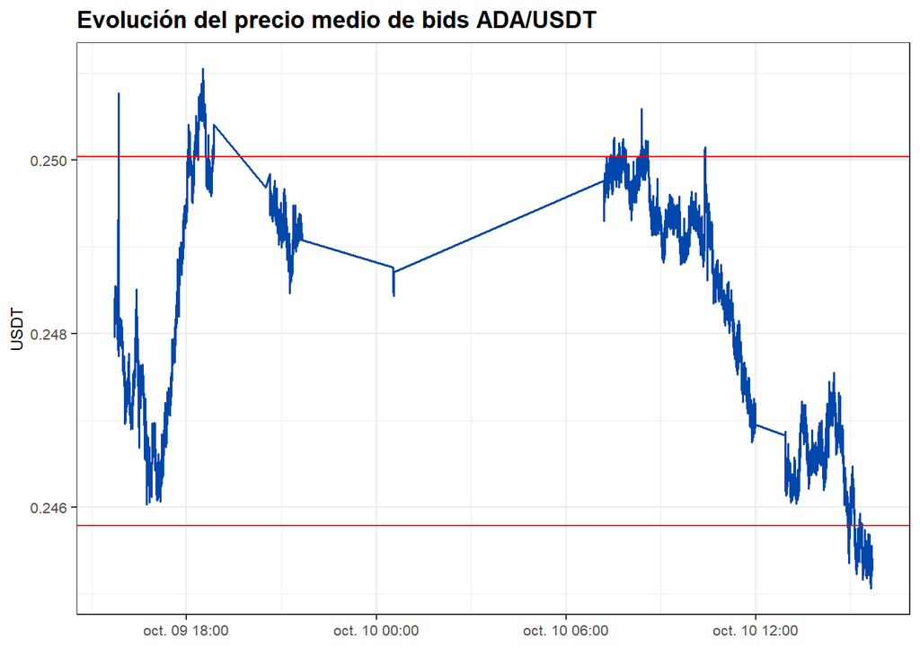

```r
grafica_evolucion_media_bids(datos_ADA_USDT, "10 sec", "Evolución del precio medio de bids ADA/USDT", "USDT", 1)
```

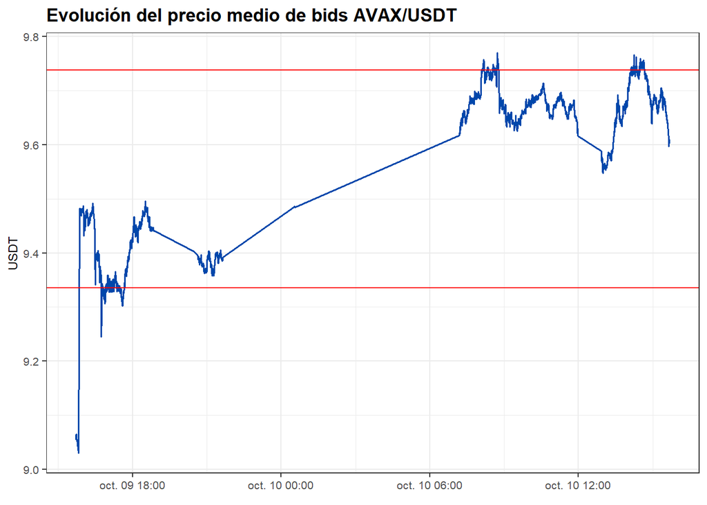

```r
grafica_evolucion_media_bids(datos_AVAX_USDT, "10 sec", "Evolución del precio medio de bids AVAX/USDT", "USDT", 2)
```

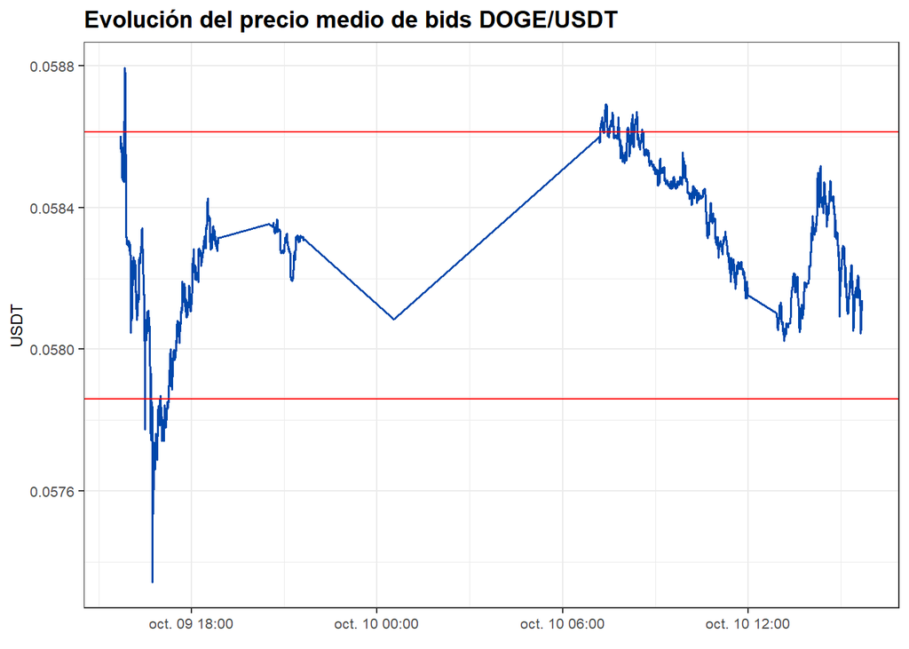

```r
grafica_evolucion_media_bids(datos_DOGE_USDT, "10 sec", "Evolución del precio medio de bids DOGE/USDT", "USDT", 3)
```

[figure not shown]

```r
grafica_evolucion_media_bids(datos_DOT_USDT, "10 sec", "Evolución del precio medio de bids DOT/USDT", "USDT", 4)
```

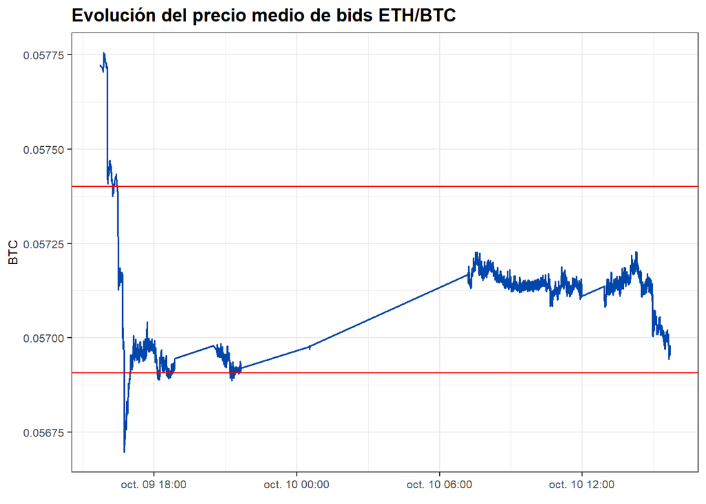

```r
grafica_evolucion_media_bids(datos_ETH_BTC, "10 sec", "Evolución del precio medio de bids ETH/BTC", "BTC", 5)
```

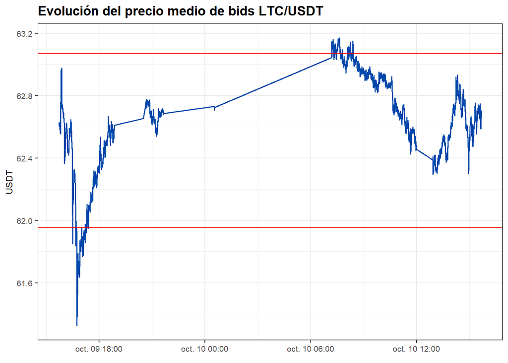

```r
grafica_evolucion_media_bids(datos_LTC_USDT, "10 sec", "Evolución del precio medio de bids LTC/USDT", "USDT", 6)
```

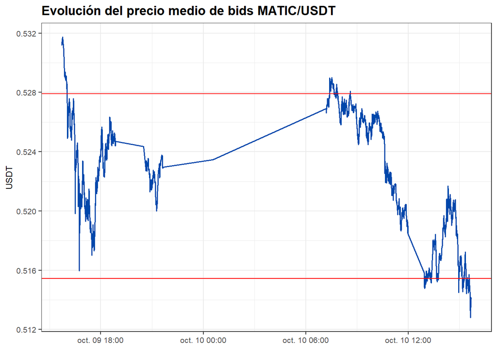

```r
grafica_evolucion_media_bids(datos_MATIC_USDT, "10 sec", "Evolución del precio medio de bids MATIC/USDT", "USDT", 7)
```

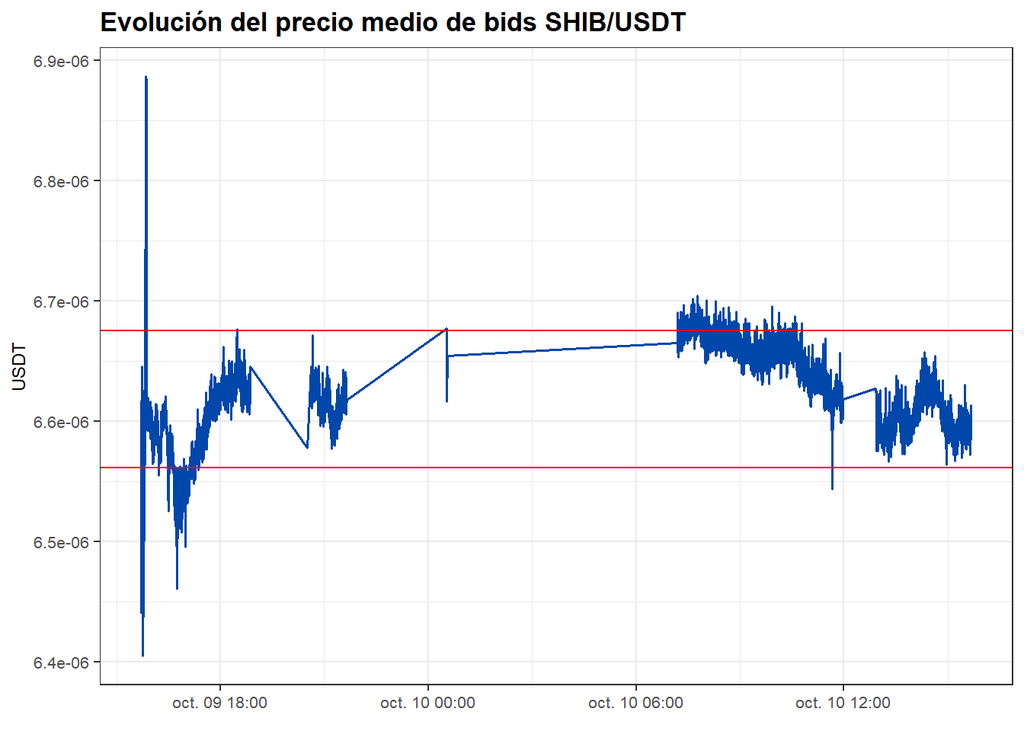

```r
grafica_evolucion_media_bids(datos_SHIB_USDT, "10 sec", "Evolución del precio medio de bids SHIB/USDT", "USDT", 8)
```

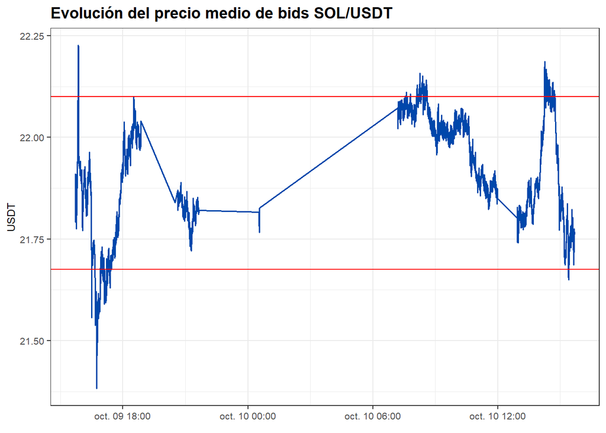

```r
grafica_evolucion_media_bids(datos_SOL_USDT, "10 sec", "Evolución del precio medio de bids SOL/USDT", "USDT", 9)
```

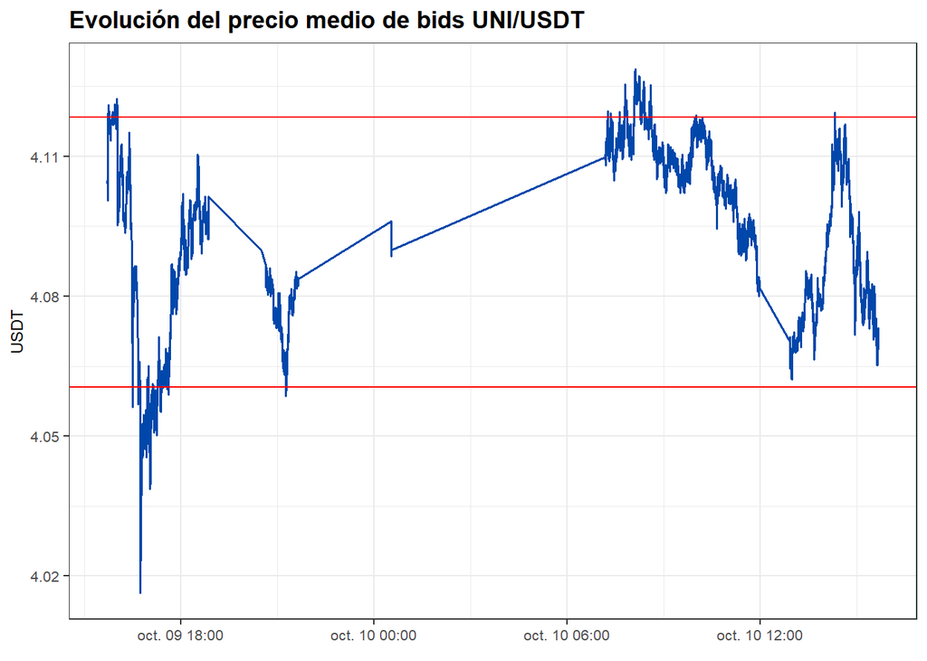

```r
grafica_evolucion_media_bids(datos_UNI_USDT, "10 sec", "Evolución del precio medio de bids UNI/USDT", "USDT", 10)
```

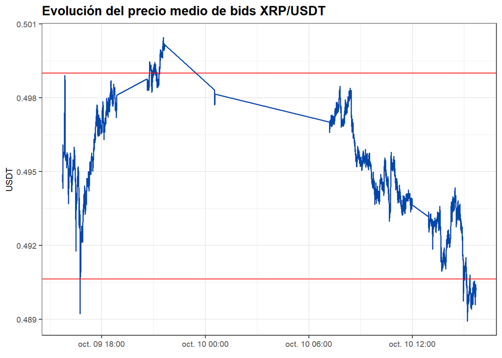

```r
grafica_evolucion_media_bids(datos_XRP_USDT, "10 sec", "Evolución del precio medio de bids XRP/USDT", "USDT", 11)
```

[figure not shown]

```r
grafica_evolucion_media_bids(datos_BTC_USDT, "10 sec", "Evolución del precio medio de bids BTC/USDT", "USDT", 12)
```

```r
grafica_evolucion_media_asks <- function (datos, time_lag, titulo_grafico, y_label) {
  datos_agrupados <- datos %>%
    mutate(Hora_agrupada = cut(Hora, breaks = time_lag)) %>%
    group_by(Hora_agrupada) %>%
    summarize(mediaAsksAgrupada = mean(mediaAsks)) %>%
    mutate(Hora_agrupada = as.POSIXct(Hora_agrupada))

  ggplot(datos_agrupados, aes(x = Hora_agrupada, y = mediaAsksAgrupada, group = 1)) +
    geom_line(size = 0.7, color = "#5F9EA0") +
    ggtitle(titulo_grafico) +
    theme_bw() +
    theme(axis.text = element_text(size = 8), axis.title =  element_text(size = 9), plot.title = element_text(face = 'bold')) +
    labs(x = element_blank(), y = y_label) +
    geom_hline(yintercept = quantile(datos_agrupados$mediaAsksAgrupada, c(.05, .95)), color = "red")
}
```

[figure not shown]

```r
grafica_evolucion_media_asks(datos_ADA_USDT, "10 sec", "Evolución del precio medio de bids ADA/USDT", "USDT")
```

[figure not shown]

```r
grafica_evolucion_media_asks(datos_AVAX_USDT, "10 sec", "Evolución del precio medio de bids AVAX/USDT", "USDT")
```

[figure not shown]

```r
grafica_evolucion_media_asks(datos_DOGE_USDT, "10 sec", "Evolución del precio medio de bids DOGE/USDT", "USDT")
```

[figure not shown]

```r
grafica_evolucion_media_asks(datos_DOT_USDT, "10 sec", "Evolución del precio medio de bids DOT/USDT", "USDT")
```

[figure not shown]

```r
grafica_evolucion_media_asks(datos_ETH_BTC, "10 sec", "Evolución del precio medio de bids ETH/BTC", "BTC")
```

[figure not shown]

```r
grafica_evolucion_media_asks(datos_LTC_USDT, "10 sec", "Evolución del precio medio de bids LTC/USDT", "USDT")
```

[figure not shown]

```r
grafica_evolucion_media_asks(datos_MATIC_USDT, "10 sec", "Evolución del precio medio de bids MATIC/USDT", "USDT")
```

[figure not shown]

```r
grafica_evolucion_media_asks(datos_SHIB_USDT, "10 sec", "Evolución del precio medio de bids SHIB/USDT", "USDT")
```

[figure not shown]

```r
grafica_evolucion_media_asks(datos_SOL_USDT, "10 sec", "Evolución del precio medio de bids SOL/USDT", "USDT")
```

[figure not shown]

```r
grafica_evolucion_media_asks(datos_UNI_USDT, "10 sec", "Evolución del precio medio de bids UNI/USDT", "USDT")
```

[figure not shown]

```r
grafica_evolucion_media_asks(datos_XRP_USDT, "10 sec", "Evolución del precio medio de bids XRP/USDT", "USDT")
```

[figure not shown]

```r
grafica_evolucion_media_asks(datos_BTC_USDT, "10 sec", "Evolución del precio medio de bids BTC/USDT", "USDT")
```

```r
grafica_evolucion_media_bids_asks <- function (datos, time_lag, titulo_grafico, y_label) {
  datos_agrupados <- datos %>%
    mutate(Hora_agrupada = cut(Hora, breaks = time_lag)) %>%
    group_by(Hora_agrupada) %>%
    summarize(mediaBidsAgrupada = mean(mediaBids), mediaAsksAgrupada = mean(mediaAsks)) %>%
    mutate(Hora_agrupada = as.POSIXct(Hora_agrupada))

  ggplot(datos_agrupados, aes()) +
    geom_line(aes(x = Hora_agrupada, y = mediaBidsAgrupada, color = "Bids"), size = 0.7) +
    geom_line(aes(x = Hora_agrupada, y = mediaAsksAgrupada, color = "Asks"), size = 0.7) +
    ggtitle(titulo_grafico) +
    theme_bw() +
    theme(axis.text = element_text(size = 8), axis.title =  element_text(size = 9), plot.title = element_text(face = 'bold')) +
    labs(x = element_blank(), y = y_label) +
    scale_color_manual(name="Series",
                     values=c("#0047AB", "#5F9EA0"))
}
```

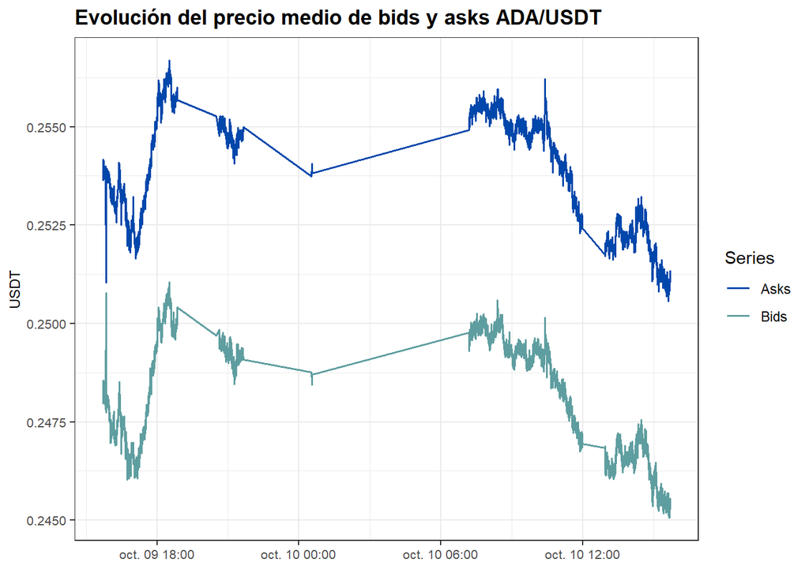

```r
grafica_evolucion_media_bids_asks(datos_ADA_USDT, "10 sec", "Evolución del precio medio de bids y asks ADA/USDT", "USDT")
```